# MAP Analysis

Last compiled on 12 July, 2023

City Year Tulsa enrolled 791 students in ELA focus list for 21 weeks typically and 685 in Math focus list for 21 weeks typically

## Dosage Distribution

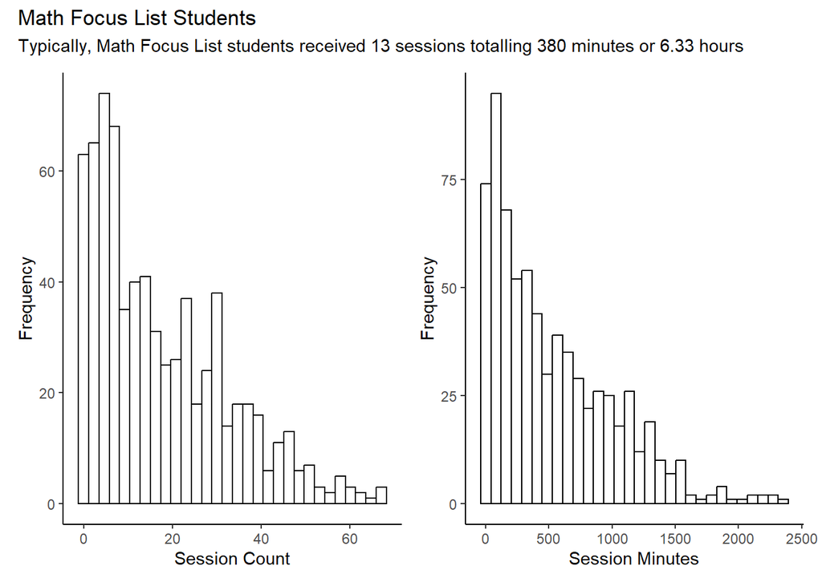

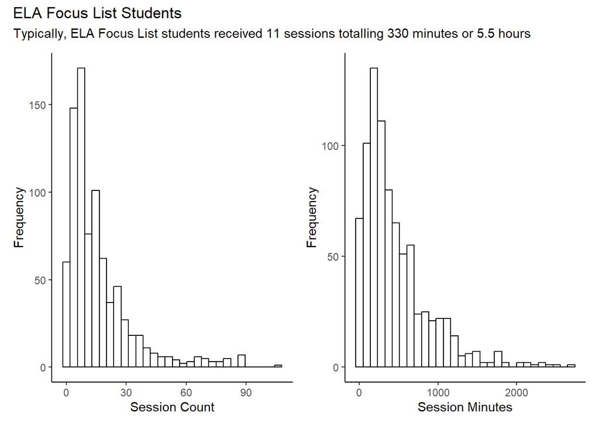

## H<sub>0</sub>: There Is No Significant Difference On Spring MAP Percentile Score For Focus List and Non-Focus List Students (ELA and Math Focus List)

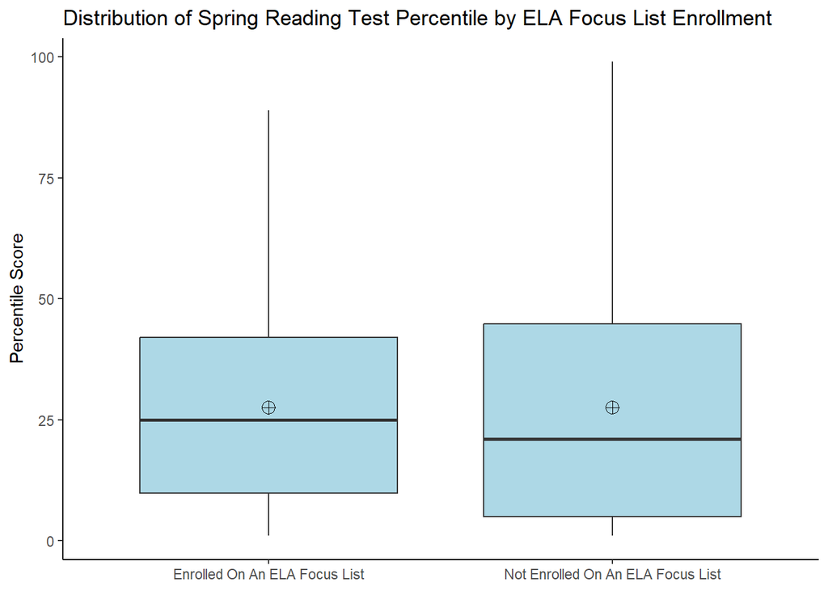

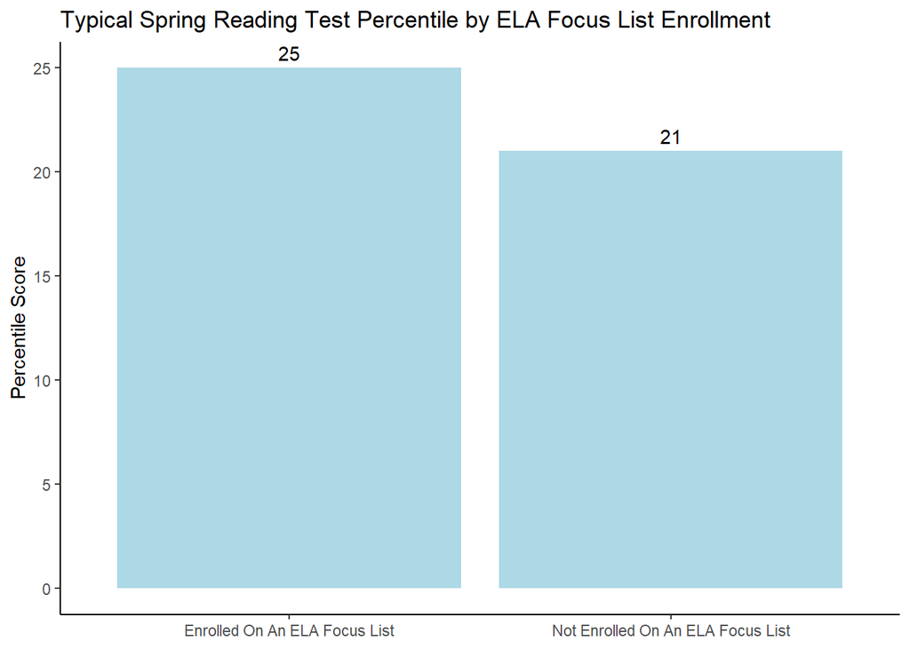

```
##
##  Wilcoxon rank sum test with continuity correction
##
## data:  testpercentile by factor(in_FL)
## W = 1215429, p-value = 0.0483
## alternative hypothesis: true location shift is not equal to 0
```

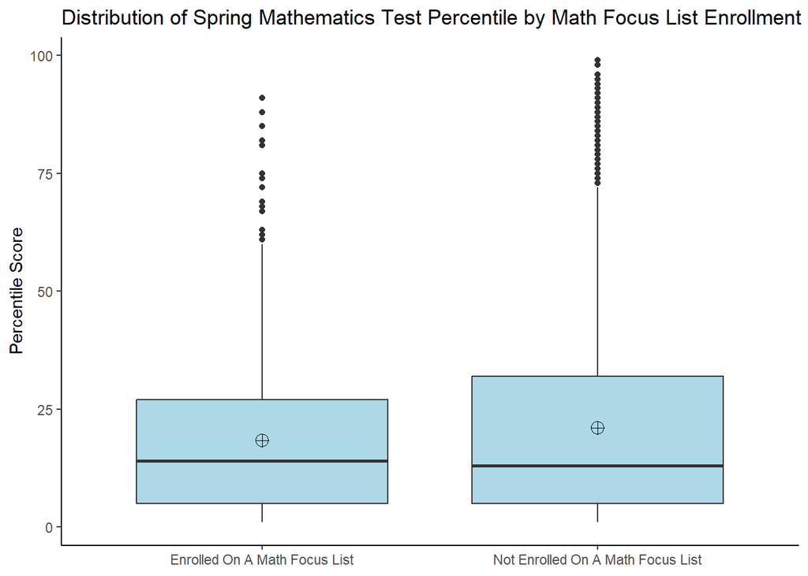

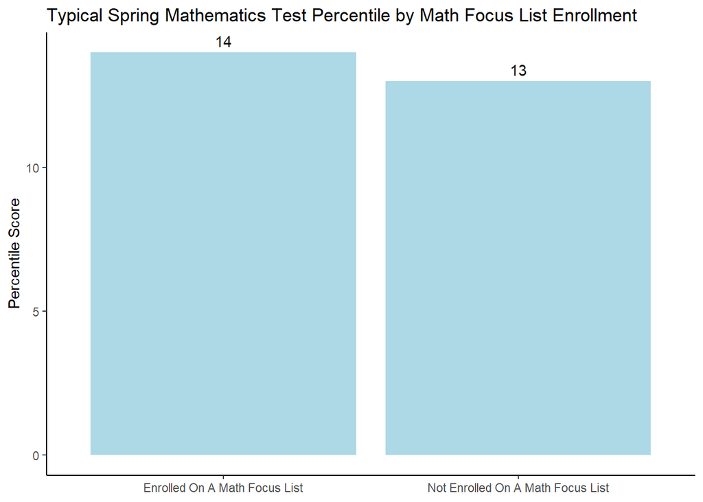

```
##
##  Wilcoxon rank sum test with continuity correction
##
## data:  testpercentile by factor(in_FL)
## W = 1236918, p-value = 0.4774
## alternative hypothesis: true location shift is not equal to 0
```

1. ELA focus list students enrolled before the Spring MAP Test received a typical median percentile score of **25** compared to **21** for non-ELA focus list students.

Using the Mann-Whitney U test to compare the MAP Reading percentile scores between ELA focus list and non ELA focus list students, the test results revealed a statistically significant difference in the grade scores between the two groups (p-value = 0.048304)

2. Math focus list students enrolled before the Spring MAP Test received a typical median percentile score of **14** compared to **13** for non-math focus list students.

Conclusion: **Students enrolled in ELA focus list have a statistically significant difference of Spring MAP test percentile score compared to students not enrolled on an ELA focus list, however, there is no statistical significant difference of Spring MAP test percentile score for Mathematics focus list students when comparing students not enrolled on a Mathematics focus list**

## H<sub>0</sub>: There Is No Significant Difference In MAP Percentile Growth Scores From Fall to Spring For Students Enrolled On an ELA/Math Focus List

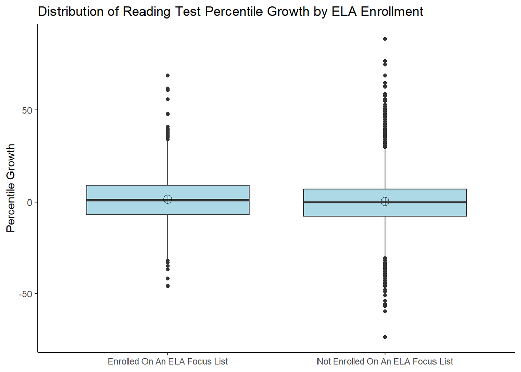

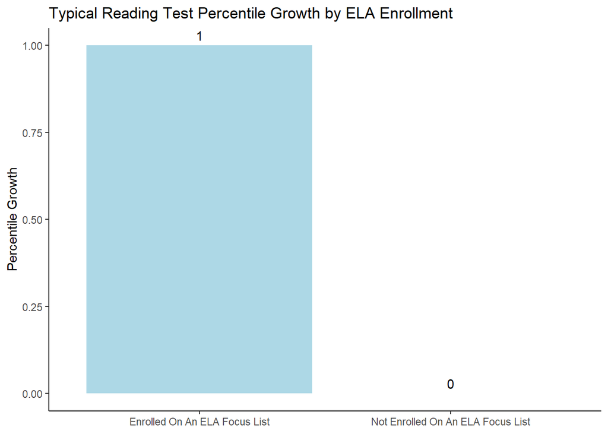

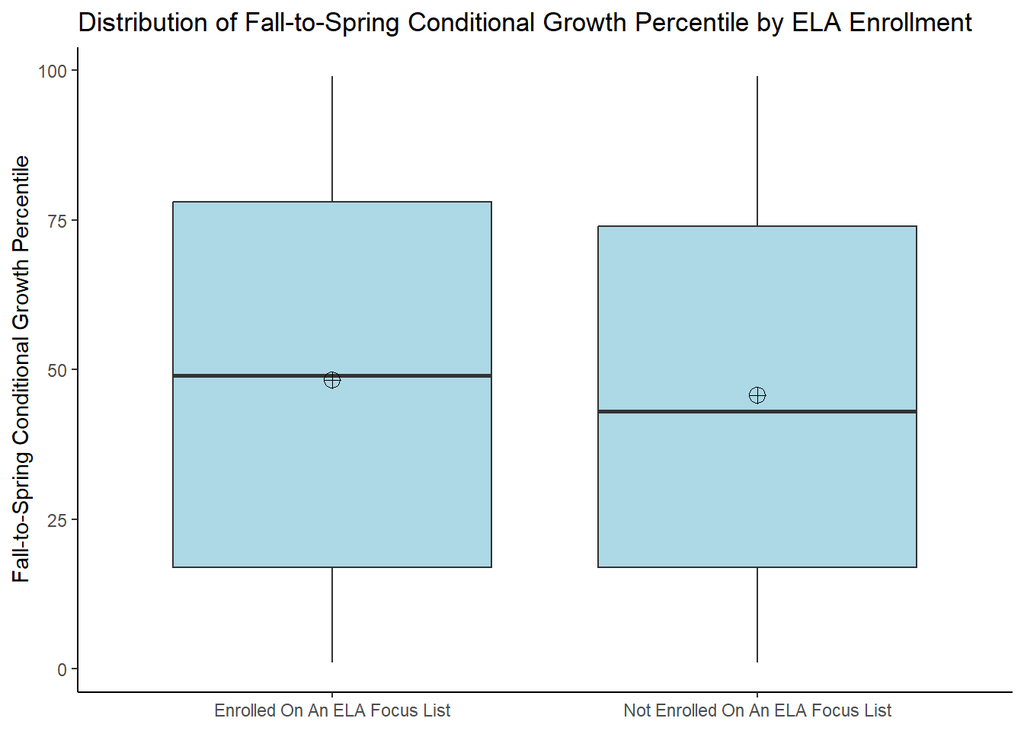

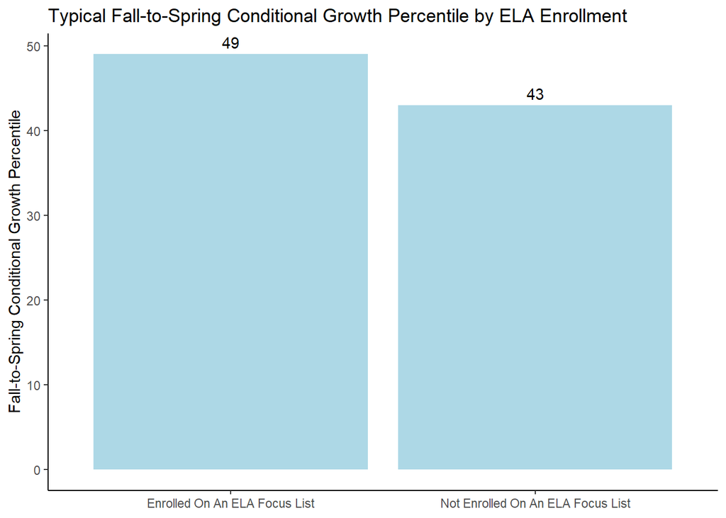

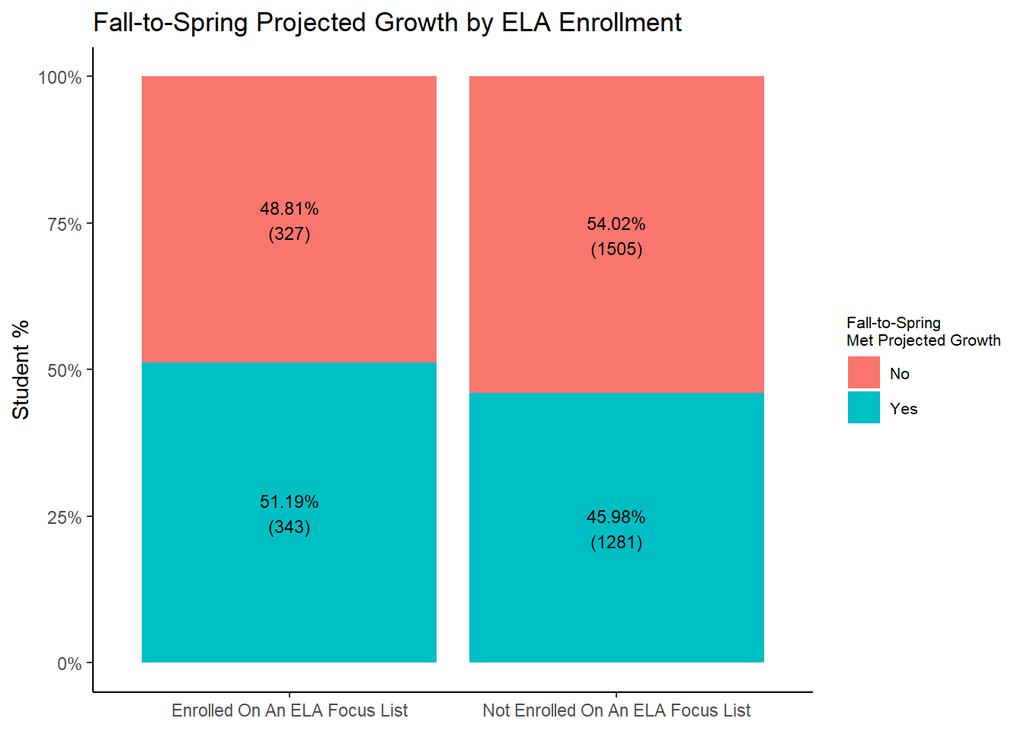

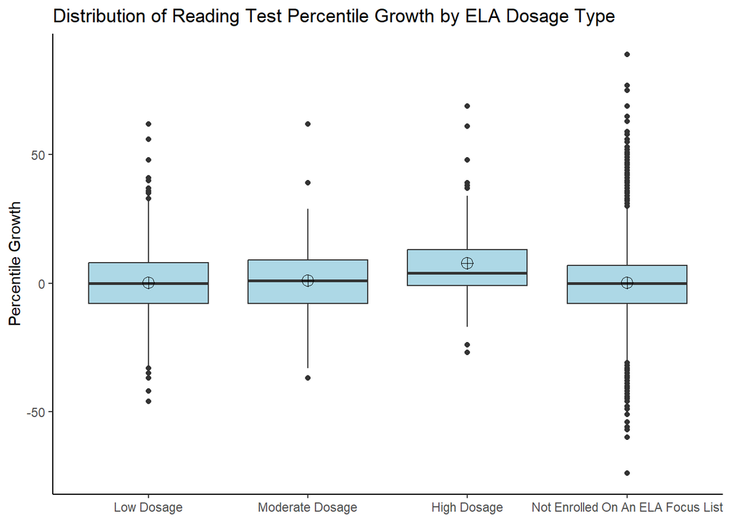

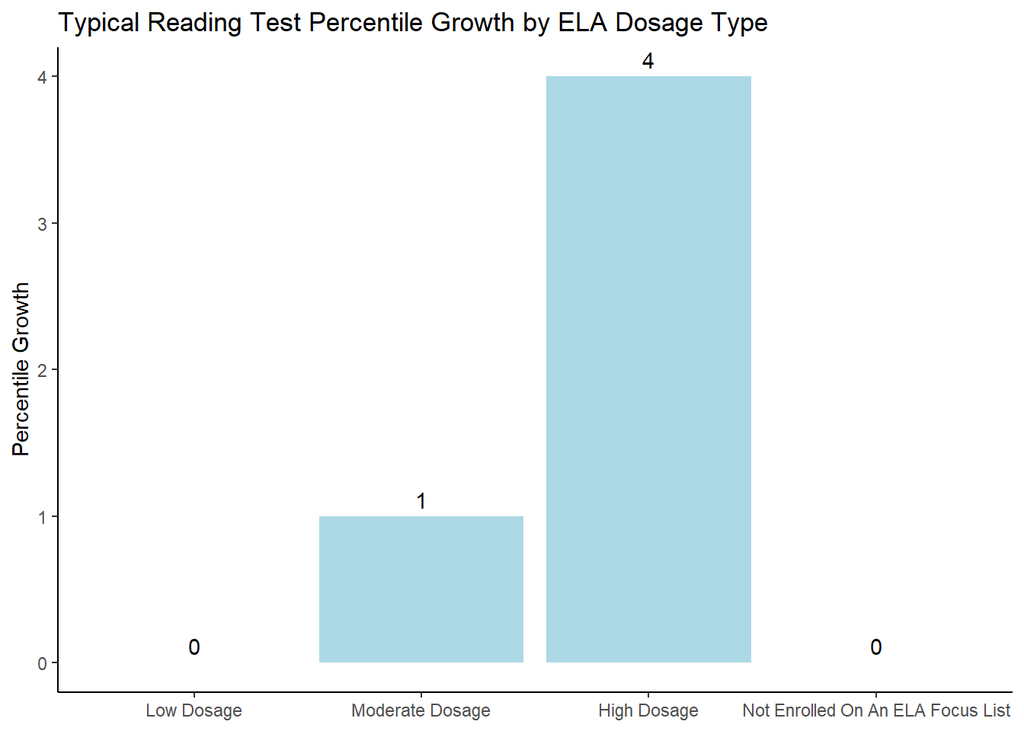

```
##               Df Sum Sq Mean Sq F value  Pr(>F)
## dosage_type    3   5208  1736.2   7.488 5.4e-05 ***
## Residuals   3459 802002   231.9
## ---
## Signif. codes:  0 '***' 0.001 '**' 0.01 '*' 0.05 '.' 0.1 ' ' 1
```

```
##   Tukey multiple comparisons of means
##     95% family-wise confidence level
##
## Fit: aov(formula = testpercentile_growth ~ dosage_type, data = map_growth_spring_ELA)
##
## $dosage_type
##                                                         diff        lwr
## Low Dosage-High Dosage                            -7.6568143 -12.219127
## Moderate Dosage-High Dosage                       -6.8172189 -12.010187
## Not Enrolled On An ELA Focus List-High Dosage     -7.7098170 -11.923985
## Moderate Dosage-Low Dosage                         0.8395954  -2.815596
## Not Enrolled On An ELA Focus List-Low Dosage      -0.0530027  -2.090825
## Not Enrolled On An ELA Focus List-Moderate Dosage -0.8925981  -4.102729
##                                                         upr     p adj
## Low Dosage-High Dosage                            -3.094502 0.0000972
## Moderate Dosage-High Dosage                       -1.624251 0.0041662
## Not Enrolled On An ELA Focus List-High Dosage     -3.495649 0.0000159
## Moderate Dosage-Low Dosage                         4.494787 0.9350162
## Not Enrolled On An ELA Focus List-Low Dosage       1.984820 0.9998928
## Not Enrolled On An ELA Focus List-Moderate Dosage  2.317533 0.8913065
```

- ELA focus list students enrolled before the Spring MAP Test grew by **1** percentage points on their Reading MAP Test compared to **0** for students not enrolled on an ELA focus list.
- ELA focus list students enrolled before the Spring MAP Test has a typical fall-to-spring conditional growth of **49** percentage points on their Reading MAP Test compared to **43** for non-ELA focus list students.

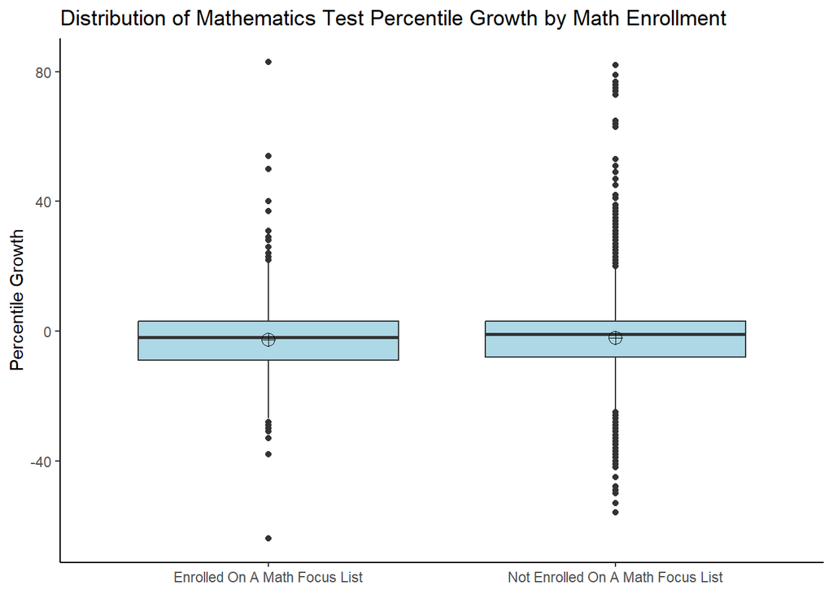

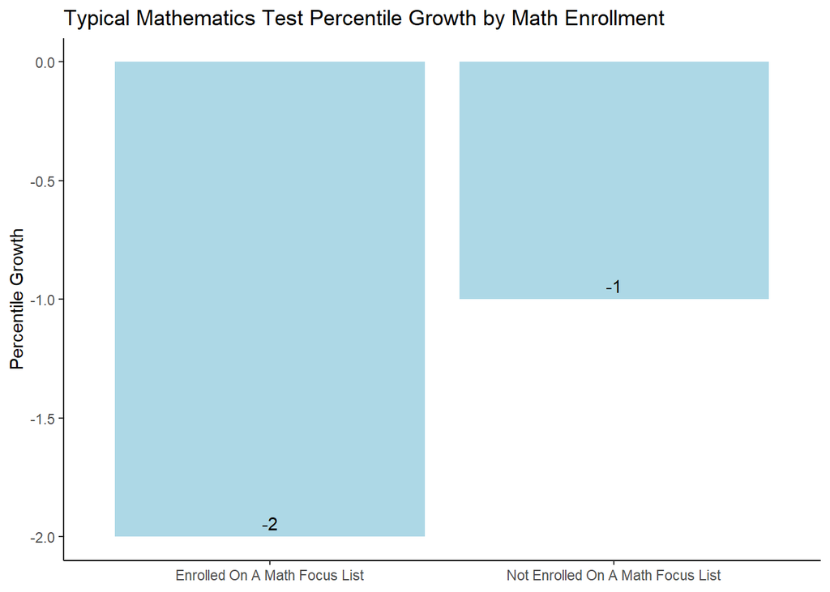

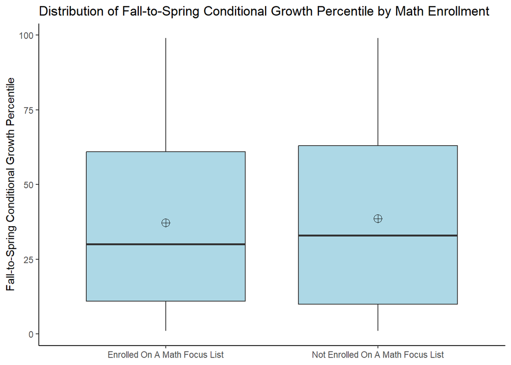

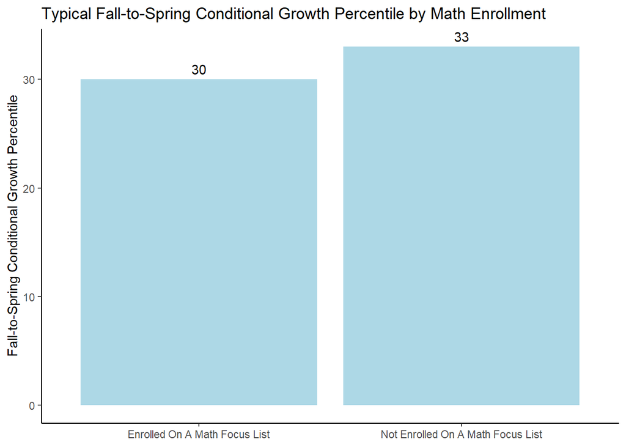

```
##
##  Wilcoxon rank sum test with continuity correction
##
## data:  falltospringconditionalgrowthper by factor(in_FL)
## W = 807789, p-value = 0.4385
## alternative hypothesis: true location shift is not equal to 0
```

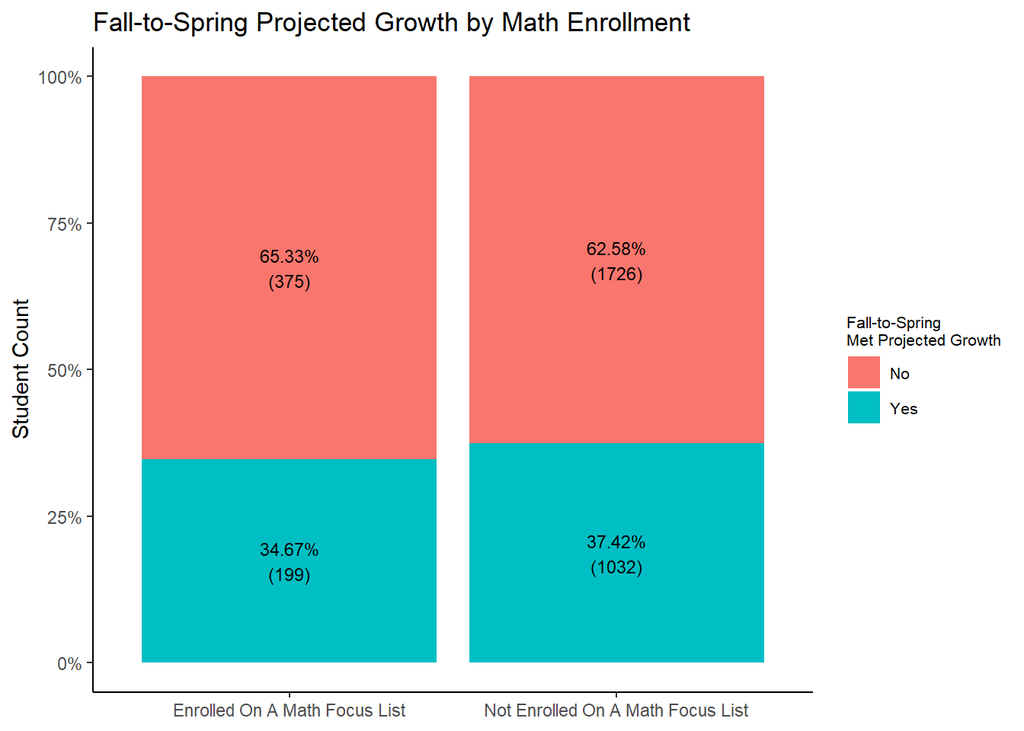

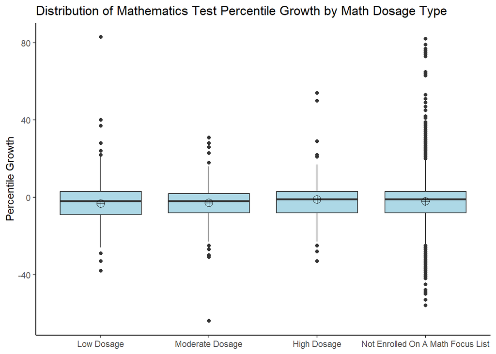

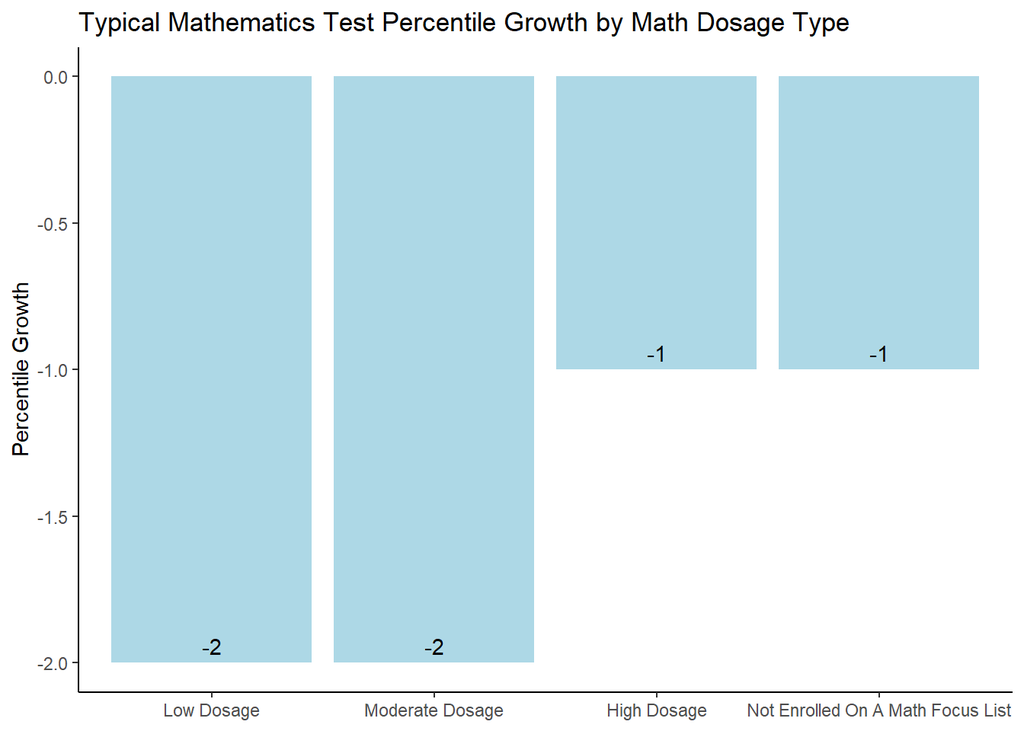

```
##               Df Sum Sq Mean Sq F value Pr(>F)
## dosage_type    3    555   184.9   1.175  0.318
## Residuals   3334 524675   157.4
```

- Math focus list students enrolled before the Spring MAP Test grew by **-2** percentage points on their Mathematics MAP Test compared to **-1** for non-Math focus list students.
- Math focus list students enrolled before the Spring MAP Test has a typical fall-to-spring conditional growth of **30** percentage points on their Mathematics MAP Test compared to **33** for non-Math focus list students.

## Percentile Growth and Projected Growth of MAP Scores for ELA/Math Focus List Students by Initial Percentile Range and Dosage Type

Dosage types are defined as: High Dosage - More than 900 minutes Moderate Dosage - 450 to 900 minutes Low Dosage - Less than 450 minutes

Definitions for Met Projected Growth categories are defined by NWEA

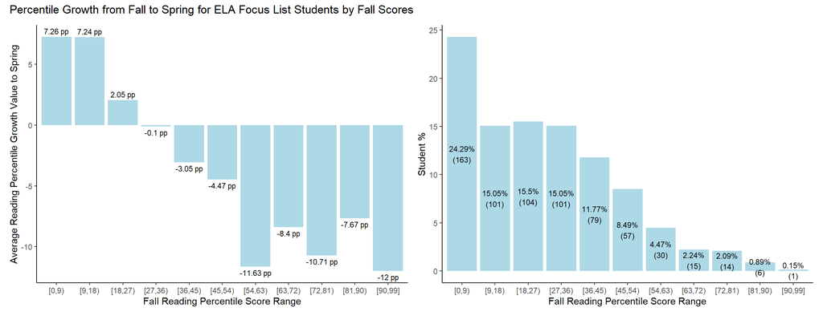

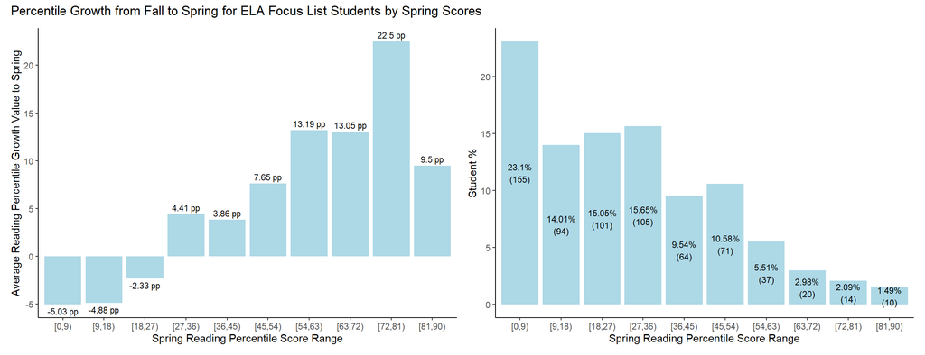

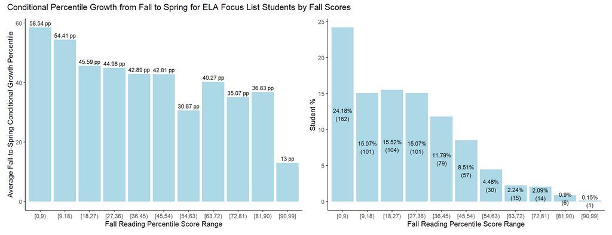

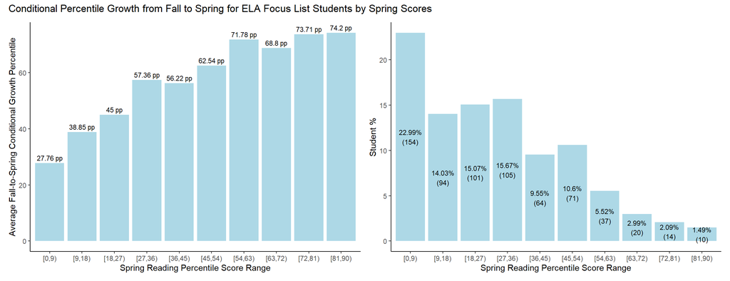

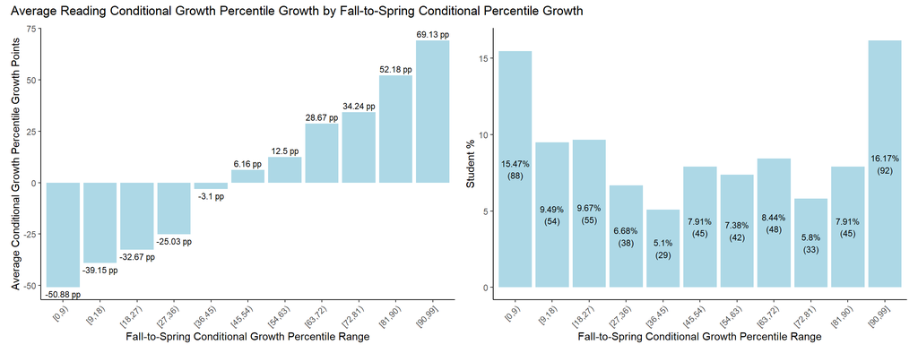

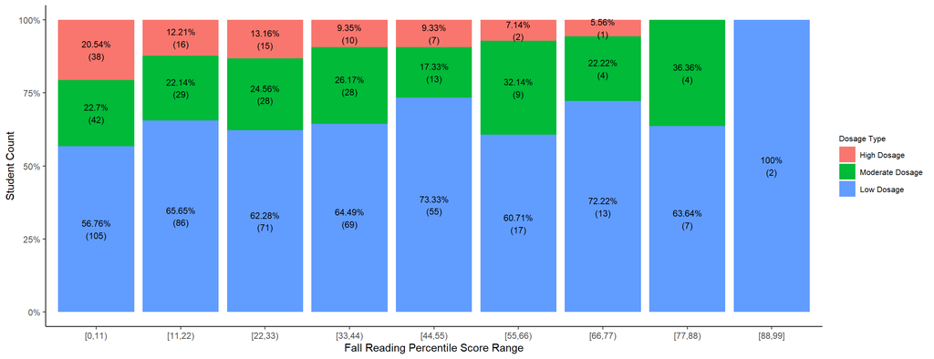

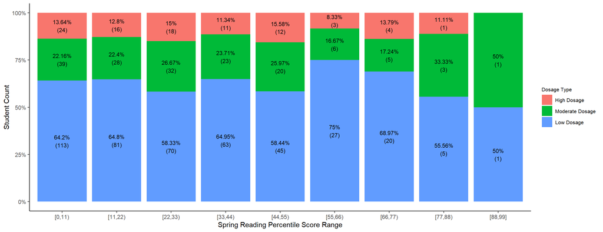

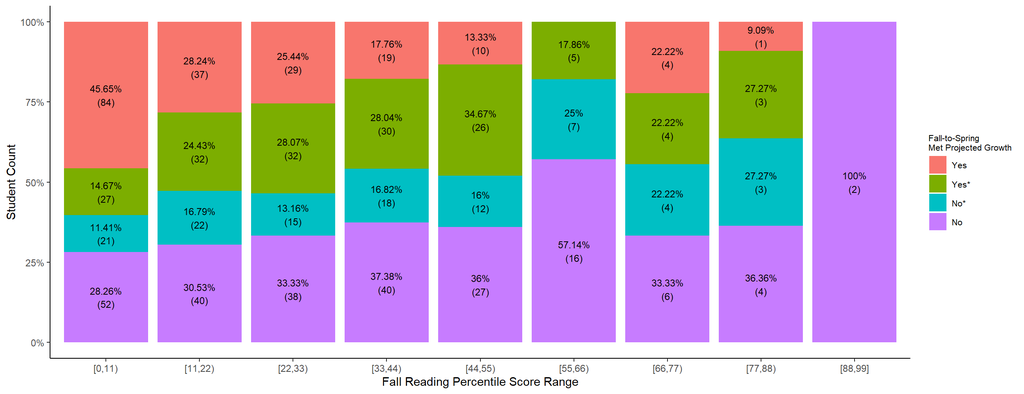

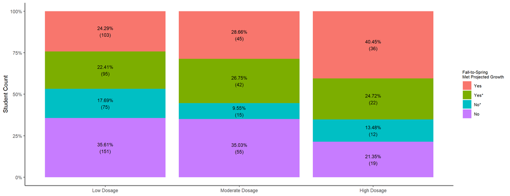

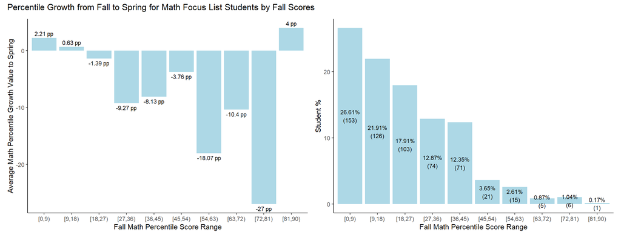

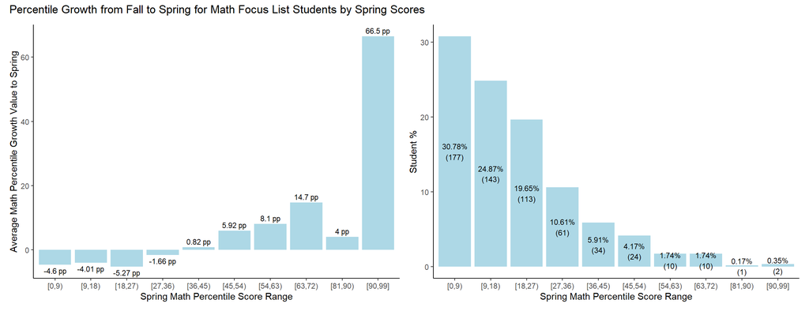

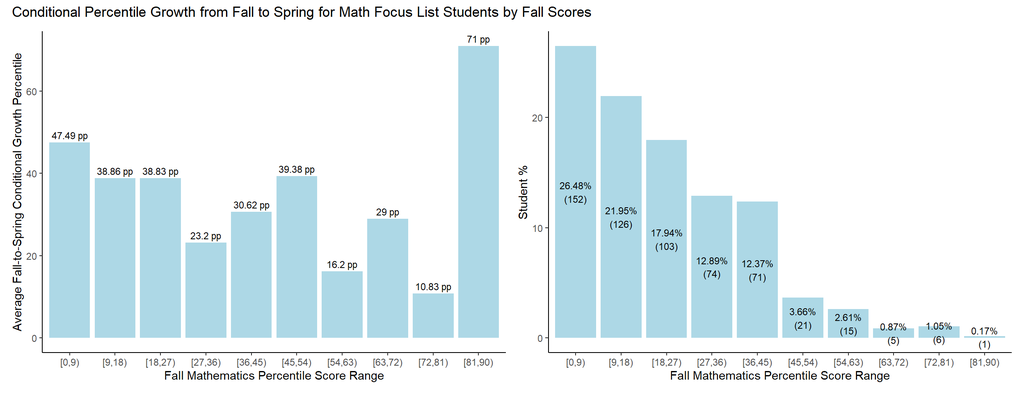

[6 more figures not shown]